# Introduction to time series analysis

## Plot time series

Generate a sample of size 100 drawn from a normal distribution with mean 3 and standard deviation 2. Plot the normally distributed sample in addition to a horizontal line representing the sample mean as shown below. Add a title, set the axes labels, line width, color, line style, and legend.

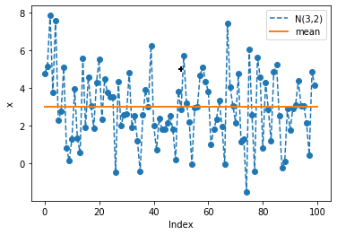

## White noise time series

Create 200 samples from a normal distribution with mean 0 and variance 1. Convert this into a pandas series with index ranging from year 1800 till 1999 (inclusive). Verify it is a time series with **type()**. Finally plot the time series as shown below.

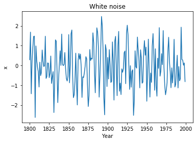

## Time series datasets

Some time series datasets (taken from R) are provided in this lab, including the series for monthly accidental deaths in the US between 1973 and 1978, as well as the level in feet of lake Huron, both of which were encountered in Chapter 1.

Read in the data for monthly accidental deaths in the US ('USAccDeaths.csv') and make a plot of the time series. Note: you may find **pd.to_datetime()** useful).

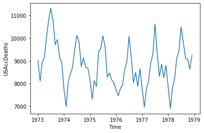

Repeat the same for the dataset `LakeHuron` ('LakeHuron.csv'), `AirPassengers` ('AirPassengers.csv') for monthly airline passenger numbers between 1949 and 1960, and `lynx` ('lynx.csv') for the annual number of lynx trappings in Canada between 1821 and 1934. The latter two time series exhibit a seasonal component, with `AirPassengers` data also showing a clear trend.

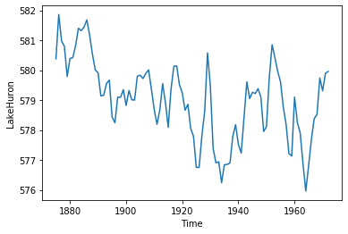

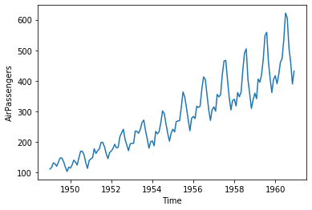

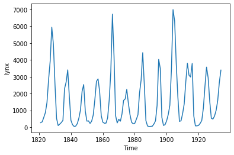

## Trend estimation by linear regression

Let us consider lake Huron data as in Example 1.3.5 of the textbook. Plot the time series again with correct years on the x-axis. Add a scatter plot of the data points. Then, fit a linear model (e.g. using sklearn's **LinearRegression()** from module **sklearn.linear_model**) and plot (predictions from) the linear model. By this, you would have created Figure 1-9 of the textbook.

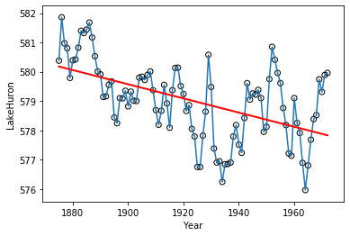

Next we plot the residuals $y - \widehat{y}$ as in Figure 1-10 of the textbook. Create a line plot of the residuals, highlight the data points, and finally show the horizontal $y=0$ line (e.g. **axhline()** is one way). Is there a trend in the residual plot? Are residuals centered around a mean of zero?

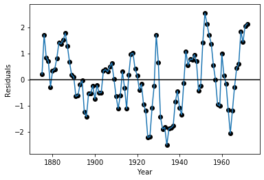

## Harmonic regression

Next, we replicate Example 1.3.6 of the textbook which illustrates harmonic regression. Plot the time series for monthly accidental deaths in the US. Inspect the numerical values in the data. How many data points does the series consist of? Create a generic index or time vector $t$ starting from 0 and of length equal to the number of data points in the series. Plot the time series as a function of $t$.

We will model the time series as a sum of two harmonics, one with period 12 months and the other with period 6 months. Therefore, create four sinusoidal series as a function of $t$: $x_1 = cos \left( 6 \frac{2\pi t}{72} \right)$, $x_2 = sin \left( 6 \frac{2\pi t}{72} \right)$, $x_3 = cos \left( 12 \frac{2\pi t}{72} \right)$, and $x_4 = sin \left( 12 \frac{2\pi t}{72} \right)$. Then fit a linear model of the actual time series against these four sinusoidal components (again you may use **LinearRegression()**). This means the time series will be a linear function of these four sinusoids, and the coefficients before the sinusoidal terms are estimated by the least-squares method. Finally, inspect the fitted values of the model (method: **predict()**), and plot the time series while superimposing a line plot of the fitted values. By this, we would have reproduced Figure 1-11 of the textbook.

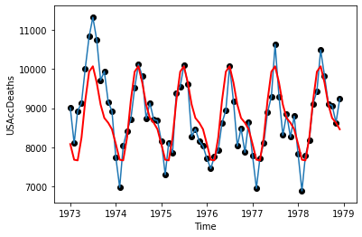

## AR(1) assumption

As in Figure 1-15 of the textbook, plot the autocorrelation function (ACF) for the residuals resulting from fitting a linear model to the lake Huron time series (hint: **acf()** from **statsmodels.tsa.stattools**). Let this be a stem plot (**plt.stem()**) and add confidence bounds as described in the lecture slides. Does the ACF resemble that of white noise? Apart for $\rho(0)$, how many autocorrelations fall outside the confidence bounds? Note: the ACF can equivalently be plotted using **plot_acf()** (from **statsmodels.graphics.tsaplots**).

To check the AR(1) assumption, create a scatter plot of the residuals $y(t)$ versus $y(t-1)$ for $t=1,...,n$ where $n$ is the number of data points in the residual series. Does the plot indicate a $y(t) = \phi y(t-1)$ relationship? Fit a linear model and add the straight line plot as in Figure 1-16 of the textbook. What is the estimated $\phi$ (hint: attribute **coef_**).

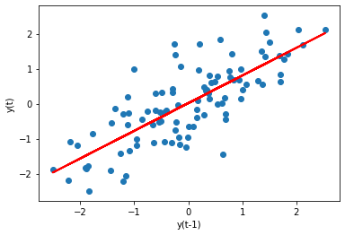

## ACVF and ACF

The autocovariance function can be obtained from **acovf()** (module: **statsmodels.tsa.stattools**). Plot the time series for monthly accidental deaths in the US, which clearly shows a seasonal component. Plot the ACF and the ACVF. Would you expect the ACVF and ACF plots to also exhibit seasonality?

Generate a random sample of size 200 from a normal distribution with mean 0 and variance 1. Plot the ACF as in Figure 1-13 of the textbook (Example 1.4.6). What is the main characteristic of the ACF plot in the case of white noise?

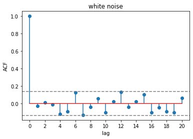

## Theoretical ACF versus sample ACF

### White noise

Generate 100 random samples drawn from a normal distribution of mean 0 and standard deviation 2. Plot the sample ACF and highlight the theoretical values at lags 0 through 20.

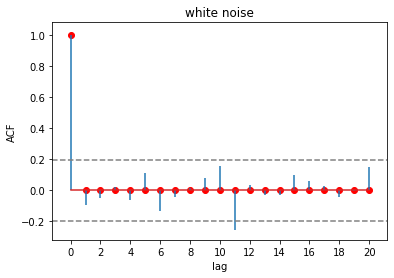

### MA(1) process

Recall that the MA(1)-process defined by

$$X_t = Z_t + \theta Z_{t-1}$$

has the following ACVF:

$$\gamma_X(t+h,t) = \begin{cases} \sigma^2(1+ \theta^2), & \text{if $h=0$} \\ \sigma^2 \theta, & \text{if $h=\pm1$} \\ 0, & \text{if $|h|>1$} \\ \end{cases}$$

Therefore, its ACF is given by:

$$\rho_X(h) = \begin{cases} 1, & \text{if $h=0$} \\ \theta/(1+\theta^2), & \text{if $h=\pm1$} \\ 0, & \text{if $|h|>1$} \\ \end{cases}$$

Suppose we have an MA(1)-process with $\theta = 0.8$. Create an array of the theoretical ACF values $\rho(0)$ through $\rho(20)$, and plot these as a stem plot.

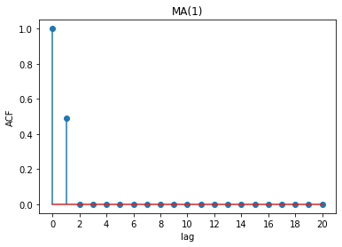

Simulate an MA(1) time series with $\theta=0.8$ using **ArmaProcess()** (module: **statsmodels.tsa.arima_process**) as shown below. The simulation utilizes the MA(1)-equation. Plot the simulated time series; also plot the sample ACF of this time series, and add the theoretical values highlighted as points. Does the plot exhibit a cutoff? If so, at which lag?

Note: another way to generate samples from an ARMA model is through **arma_generate_sample()** from the same module as above.

```python
from statsmodels.tsa.arima_process import ArmaProcess

ar_params = np.array([1])
#ar_params = np.r_[1, -ar_params] #add zero-lag and negate if  ARMA actually has an AR component
ma_params = np.array([.8])
ma_params = np.r_[1, ma_params] # add zero-lag

model = ArmaProcess(ar_params, ma_params)
y_simulated = model.generate_sample(nsample=100)
```

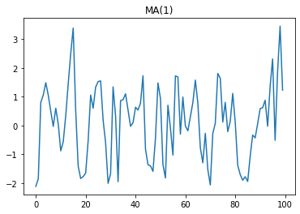

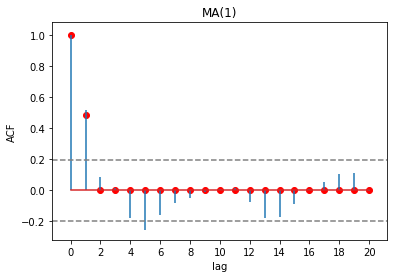

### AR(1) process

Recall that the AR(1)-process defined by

$$X_t = \phi X_{t-1} + Z_t$$

has the following ACVF:

$$\gamma_X(h) = \dfrac{\sigma^2}{1-\phi^2} \phi^{|h|}$$

Therefore, its ACF is given by:

$$\rho_X(h) = \phi^{|h|}$$

Suppose we have an AR(1)-process with $\phi = -0.5$. Create an array of the theoretical ACF values $\rho(0)$ through $\rho(20)$, and plot these as a stem plot.

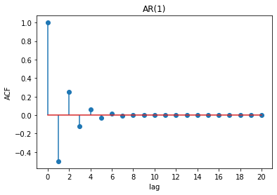

Simulate an AR(1) time series with $\phi=-0.5$ (again using **ArmaProcess()**). Plot the simulated time series; also plot the sample ACF of this time series, and add the theoretical values highlighted as points.

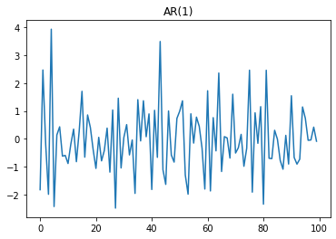

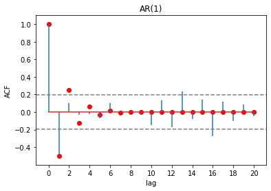

Another way to compute the theoretical ACF (instead of manually) is through the method **acf()** once you have already specified a model. For example, with AR(1) process previously encountered, we may obtain the theoretical ACF values as shown below.

```python
#alternatively: use method .acf()
acf_theoretical = (-0.5)**np.arange(20+1) #manually
acf_theoretical = model.acf(lags=20+1)    #same result
```

### ARMA(2,2) process

Now, compute the theoretical ACF values for the following ARMA(2,2) process:

$$X_t + 0.3 X_{t-1} - 0.1 X_{t-2} = Z_t + 0.5 Z_{t-1} + 0.8 Z_{t-2}$$

Simulate and show a time series from the above ARMA(2,2) process. Plot the sample ACF, and add the theoretical values as points.

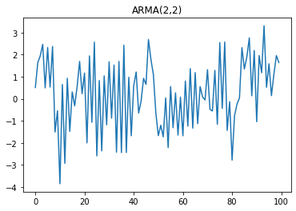

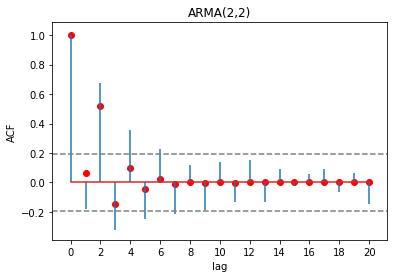

## Partial autocorrelation function (PACF)

A model created with **ArmaProcess()** also has a method for obtaining the theoretical partial autocorrelation function (PACF) using **pacf()**. For example, the below code creates the PACF for an AR(3) process. Plot the sample PACF, and add the theoretical values as points. Observing the PACF plot for the AR(3) process, is there a clear cutoff? If so, at which lag?

```python
#AR(3) process
ar_params = np.array([0.5, -0.2, 0.1])
ar_params = np.r_[1, -ar_params] #add zero-lag and negate
ma_params = np.array([1])

model = ArmaProcess(ar_params, ma_params)
```

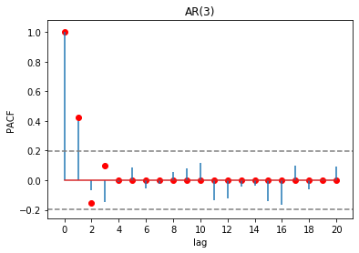